# Competition Assignment

Daniel Schmidtner

2023-02-08

## Load Data

```r
training_test_data <- fread(here("input_data", "trainig_test_data.csv"))

holdout_data <- fread(here("input_data", "holdout_data.csv"))
```

## Check for NAs

First we check for NAs in our data by using sapply to run the sum function through each of the columns. Next we convert each of the character columns to factorials.

```r
sapply(training_test_data, function(x) sum(is.na(x)))
```

```
##           income            state             line       workhours1
##                0                0              125             2481
##            class              age         marriage             race
##                0                0                0                0
##              sex          veteran          region2             city
##                0             1978                0             9207
##        ethnicity     agricultural status_last_week           class2
##               18                0               56              137
##       workhours2       paidbyhour         income_a         income_b
##              886              974                0                0
##         income_c         income_d            union         industry
##                0                0              961                0
##         children       child_info  family_relation       occupation
##             9751                0                0                0
## family_reference        education
##                0             1144
```

```r
sapply(holdout_data, function(x) sum(is.na(x)))
```

```
##            state             line       workhours1            class
##                0               12              270                0
##              age         marriage             race              sex
##                0                0                0                0
##          veteran          region2             city        ethnicity
##              249                0              991                1
##     agricultural status_last_week           class2       workhours2
##                0                4               15               94
##       paidbyhour         income_a         income_b         income_c
##              106                0                0                0
##         income_d            union         industry         children
##                0              112                0             1104
##       child_info  family_relation       occupation family_reference
##                0                0                0                0
##        education
##              140
```

```r
training_test_data <- as.data.frame(unclass(training_test_data), stringsAsFactors = TRUE) # Convert all character columns to factor

holdout_data <- as.data.frame(unclass(holdout_data), stringsAsFactors = TRUE) # Convert all character columns to factor
```

## NA imputation

To impute the NAs in the dataframe we used the package Missranger, which employs a random forest based imputation.

```r
# training_test_data$children <- training_test_data$children |>
#   replace_na(0)
#
# holdout_data$children <- holdout_data$children |>
#   replace_na(0)

training_test_data_imputed <- missRanger(data = training_test_data,
                                         formula = . -children ~ . -children,
                                         num.trees = 20)
```

```
##
## Missing value imputation by random forests
##
##   Variables to impute:       line, workhours1, veteran, city, ethnicity, status_last_week, class2, workhours2, paidbyhour, union, education
##   Variables used to impute:  income, state, line, workhours1, class, age, marriage, race, sex, veteran, region2, city, ethnicity, agricultural, status_last_week, class2, workhours2, paidbyhour, income_a, income_b, income_c, income_d, union, industry, child_info, family_relation, occupation, famil…
## iter 1:  ...........
## iter 2:  ...........
## iter 3:  ...........
## iter 4:  ...........
## iter 5:  ...........
```

```r
holdout_data_imputed <- missRanger(data = holdout_data,
                                   formula = . -children ~ . -children,
                                   num.trees = 100)
```

```
##
## Missing value imputation by random forests
##
##   Variables to impute:       line, workhours1, veteran, city, ethnicity, status_last_week, class2, workhours2, paidbyhour, union, education
##   Variables used to impute:  state, line, workhours1, class, age, marriage, race, sex, veteran, region2, city, ethnicity, agricultural, status_last_week, class2, workhours2, paidbyhour, income_a, income_b, income_c, income_d, union, industry, child_info, family_relation, occupation, family_refere…
## iter 1:  ...........
## iter 2:  ...........
## iter 3:  ...........
```

```r
holdout_data_imputed <- holdout_data_imputed |>
  add_column(income = NA) |>
  relocate(income)

fwrite(training_test_data_imputed, here("input_data", "training_test_data_imputed.csv"))
fwrite(holdout_data_imputed, here("input_data", "holdout_data_imputed.csv"))
```

## Random Forest

In the end we didn’t use the random forest for our prediction.

mtry: number of variables randomly sampled as candidates at each split min.node.size: minimum number of observations associated with each leaf node splitrule: criterion to find optimal split points sample.fraction: fraction of observations to sample in each tree replace: whether to sample with or without replacement respect.unordered.factors: handling of unordered factors in covariates

```r
# We can tune the parameters mtry, splitrule and min.node.size

# mtry          = number of variables randomly sampled as candidates at each split
# splitrule     = criterion to find optimal split points ("variance", "gini", "information gain")
# min.node.size = minimum number of observations associated with each leaf node

# Then we decide which type of cross validation we are using for training
control5 = trainControl(method = "cv", number = 5) # number = 5 means that we use a fivefold cross-validation, the higher the number, the more precise, but it will also take longer

# control10 = trainControl(method = "cv", number = 10) # number = 5 means that we use a fivefold cross-validation, the higher the number, the more precise, but it will also take longer


# Next we set the parameters that we want to tune in the tuning grid
# in the search for the best model one can try diffenerent sequences for mtry which are the randomly selected predictors

# rf_tuning_grid1 = expand.grid(mtry = 30, splitrule = "variance", min.node.size = 300)
# rf_tuning_grid2 = expand.grid(mtry = 30, splitrule = "variance", min.node.size = 200)


# In order to optimize the model we use the train function from the caret package and train them on the different grids
# rf_caret1 = caret::train(data = training_test_data_imputed[,-25], income ~ ., method = "ranger", trControl = control5, tuneGrid = rf_tuning_grid1, importance = "impurity")

# rf_caret2 = caret::train(data = training_test_data_imputed[,-25], income ~ ., method = "ranger", trControl = control5, tuneGrid = rf_tuning_grid2, importance = "impurity")


# Now we can extract the final model from the caret package. The output is again a ranger object.
# The finalModel is chosen based on the RMSE
# rf_caret1_final = rf_caret1$finalModel
# rf_caret2_final = rf_caret2$finalModel

# saveRDS(rf_caret1, here("output_data", "rf_caret1.rds"))
# saveRDS(rf_caret2, here("output_data", "rf_caret2.rds"))

# rf_caret1 <- readRDS(here("input_data", "rf_caret1.rds"))
rf_caret2 <- readRDS(here("output_data", "rf_caret2.rds"))
```

## The variable importance plot of the best performing random forest

However, this would have been the variable importance plot for the random forest

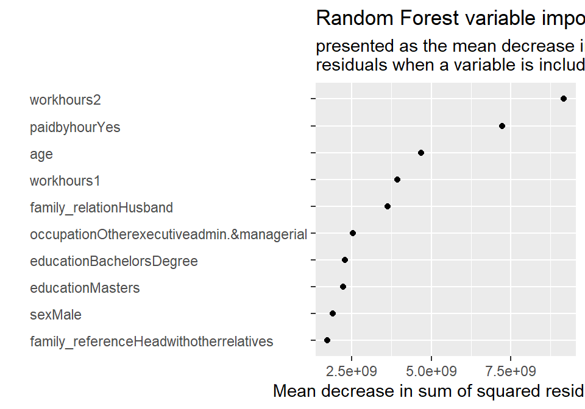

```r
rf_caret2_final = rf_caret2$finalModel

#importance
rf_caret2_importance = data.frame(importance(rf_caret2_final)[order(importance(rf_caret2_final), decreasing=TRUE)])

# adjust the row and column names of the data set
names(rf_caret2_importance) = "importance"
rf_caret2_importance$var_name = rownames(rf_caret2_importance)

# select 10 most important covariates
rf_caret2_importance = rf_caret2_importance[1:10,]

# plot variable importance scores
ggplot(rf_caret2_importance, aes(x = reorder(var_name, importance, mean), y = importance)) +
  geom_point() +
  labs(title = "Random Forest variable importance", subtitle = "presented as the mean decrease in the sum of squared \nresiduals when a variable is included in a tree split", x = "", y = "Mean decrease in sum of squared residuals") +
  coord_flip() +
  theme(axis.text.y = element_text(hjust = 0))
```

## Extreme Gradient Boosting

nrounds: maximum number of boosting iterations max_depth: maximum depth of a tree eta: learning rate of 0<eta<1 (lower value creates model that is slower to compute, but more resistant to overfitting) gamma: minimum loss reduction required to make another partition on a node colsample_bytree: fraction of columns used to construct each tree min_child_weight: minimum number of observations associated with each leaf node subsample: fraction of observations used to construct each tree

```r
# We create a tuning grid, setting the parameters that we want to tune and the corresponding values that should be tried out.
# gb_tuning_grid1 = expand.grid(nrounds = 100, max_depth = 3, eta = 0.1, gamma = 0.01, colsample_bytree = 1, min_child_weight = 1, subsample = 1)

# gb_tuning_grid2 = expand.grid(nrounds = 100, max_depth = 5, eta = 0.1, gamma = 0.01, colsample_bytree = 1, min_child_weight = 1, subsample = 1)

gb_tuning_grid3 = expand.grid(nrounds = 100, max_depth = 10, eta = 0.1, gamma = 0.01, colsample_bytree = 1, min_child_weight = 1, subsample = 1)

# gb_tuning_grid4 = expand.grid(nrounds = 100, max_depth = 15, eta = 0.1, gamma = 0.01, colsample_bytree = 1, min_child_weight = 1, subsample = 1)

# To optimize the model we combine the packages caret and xgboost.
# gb_caret1 = train(data = training_test_data_imputed[,-25], income ~ ., method = "xgbTree", trControl = control5, tuneGrid = gb_tuning_grid1, verbosity = 0) # if you don't use verbosity there will be a warning

# gb_caret2 = train(data = training_test_data_imputed[,-25], income ~ ., method = "xgbTree", trControl = control5, tuneGrid = gb_tuning_grid2, verbosity = 0) # if you don't use verbosity there will be a warning

gb_caret3 = train(data = training_test_data_imputed[,-25], income ~ ., method = "xgbTree", trControl = control5, tuneGrid = gb_tuning_grid3, verbosity = 0) # if you don't use verbosity there will be a warning

# gb_caret4 = train(data = training_test_data_imputed[,-25], income ~ ., method = "xgbTree", trControl = control5, tuneGrid = gb_tuning_grid4, verbosity = 0) # if you don't use verbosity there will be a warning

# Now we can extract the final model from the caret package. The output is an xbg.Booster object.
# gb_caret1_finalModel = gb_caret1$finalModel
# gb_caret2_finalModel = gb_caret2$finalModel
gb_caret3_finalModel = gb_caret3$finalModel


# gb_caret1
# gb_caret2
# gb_caret3
# gb_caret4

# saveRDS(gb_caret1, here("output_data", "gb_caret1.rds"))
# saveRDS(gb_caret2, here("output_data", "gb_caret2.rds"))
saveRDS(gb_caret3, here("output_data", "gb_caret3.rds"))
# saveRDS(gb_caret4, here("output_data", "gb_caret4.rds"))


gb_caret3 <- readRDS(here("output_data", "gb_caret3.rds"))

income_mypersonalfavorite = predict.train(gb_caret3, newdata = holdout_data_imputed)
income_mypersonalfavorite <- as.data.frame(income_mypersonalfavorite)


fwrite(income_mypersonalfavorite, here("output_data", "predictions.csv"))

gb_caret3
```

```
## eXtreme Gradient Boosting
##
## 47708 samples
##    28 predictor
##
## No pre-processing
## Resampling: Cross-Validated (5 fold)
## Summary of sample sizes: 38166, 38167, 38166, 38167, 38166
## Resampling results:
##
##   RMSE      Rsquared  MAE
##   964.5779  0.625     631.3798
##
## Tuning parameter 'nrounds' was held constant at a value of 100
## Tuning
##
## Tuning parameter 'min_child_weight' was held constant at a value of 1
##
## Tuning parameter 'subsample' was held constant at a value of 1
```